# Notes

Elena Kharitonova

4/4/2022

```r
library(tidyverse)
library(lme4)
library(lmerTest)
library(MuMIn)
```

```r
library(tidyverse)
library(lme4)
library(lmerTest)
library(MuMIn)
```

What we want to do: - Remove Solar Radiation - Dew Point Temperature - Visibility 10 m - Visibility 10 m

- REMOVE ALL DATA POINTS WHERE FUNCTION DAY = NO

Want to add: - Weekend variable - Try changing hours to 6 hour blocks and sum bike counts and seeing if that improves (compare using BIC value) - Try splines - Temperature change to Max and Min for day - Humidity change to be consistent with temperature

** Idea make time that is before 4 am be that of last day

Variables in Model:

- Date (Random Effect)
- Hour/Time Chunk
- Max/Min Temp
- Max/Min Humidity
- Windspeed
- Make Rain binary and Snow binary and combine
- Weekend
- Seasons
- Holiday

# Seoul bike data

## Data processing

Load in Seoul bike data

```r
seoul <- read_csv("SeoulBikeData.csv")
dim(seoul)
```

```
## [1] 8760   14
```

```r
spec(seoul)
```

[output not shown]

Non-functioning days have zero bike counts:

```r
table(seoul$`Functioning Day`)
```

```
##
##   No  Yes
##  295 8465
```

```r
any(seoul$`Rented Bike Count`[seoul$`Functioning Day` == "No"] != 0)
```

```
## [1] FALSE
```

We assume that this is when the bike system was not operating, so we will remove this from our data.

```r
seoul <- seoul %>%
  filter(`Functioning Day` == "Yes")
```

We want to combine rain and snow into a single binary variable:

```r
seoul <- seoul %>%
  mutate(Rain_or_snow = ifelse(`Rainfall(mm)` > 0 | `Snowfall (cm)` > 0, 1, 0))
table(seoul$Rain_or_snow)
```

```
##
##    0    1
## 7534  931
```

We next want to add a “weekend” variable. We can convert the `Date` column into an R Date object and use the `weekdays()` function to help us do this.

```r
seoul <- seoul %>%
  mutate(Date = as.Date(Date, format = "%d/%m/%Y")) %>%
  mutate(Weekend = ifelse(weekdays(Date) == "Saturday" | weekdays(Date) == "Sunday", 1, 0))
table(seoul$Weekend)
```

```
##
##    0    1
## 6024 2441
```

Format `Holiday` column as 0 and 1 to match other binary variables

```r
seoul <- seoul %>%
  mutate(Holiday = ifelse(Holiday == "Holiday", 1, 0))
```

Make max or min of temperature for each day

```r
temp = seoul %>% group_by(Date) %>% summarise(Min_T = min(`Temperature(C)`), Max_T = max(`Temperature(C)`))
seoul = inner_join(seoul,temp, by = "Date")
```

Make max or min of Humidity for each day

```r
hum = seoul %>% group_by(Date) %>% summarise(Min_H = min(`Humidity(%)`), Max_H = max(`Humidity(%)`))
seoul = inner_join(seoul,hum, by = "Date")
```

### Hourly version

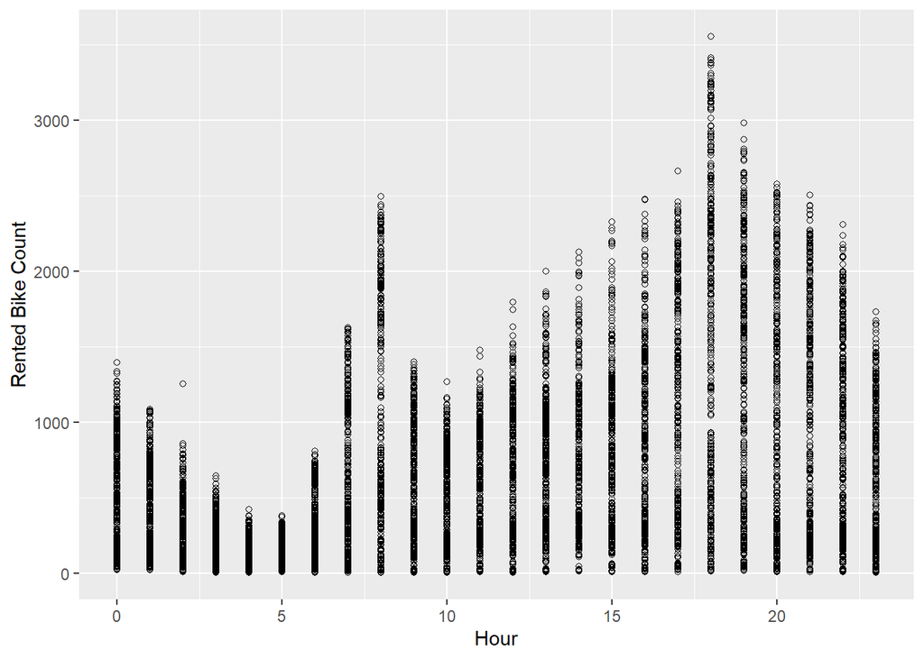

```r
ggplot(seoul, aes(x = Hour, y = `Rented Bike Count`)) + geom_point(shape = 21)
```

Standardize variable names to match across datasets

```r
seoul <- seoul %>%
  rename(Bike_count = `Rented Bike Count`,
         Wind_speed = `Wind speed (m/s)`,
         Is_weekend = Weekend,
         Season = Seasons,
         Is_holiday = Holiday)
```